# Project

This assessment is marked out of 100 and comprises 30% of the final course mark.

Due by 4pm on Wednesday November 16th 2022 (Week 9), to be submitted on Learn (DO NOT submit on Noteable).

### Academic misconduct

This assessment is summative in nature. You are expected to be aware of and abide by University policies on academic misconduct.

- [School of Mathematics academic misconduct advice and policies](https://teaching.maths.ed.ac.uk/main/undergraduate/studies/assessment/academic-misconduct)
- [Academic Services academic misconduct information](https://www.ed.ac.uk/academic-services/students/conduct/academic-misconduct)

**This is an individual assignment - do not copy the work of another student or show your own work to another student.**

If you use any resources (e.g. textbooks or websites), then you must include appropriate references in your solutions. Course materials do not need to be referenced, but you should clearly state which results you are using.

### Code commentary

Your code should be commented, with the functionality of each line of code explained. This is to test your understanding of the code you have written. Up to a quarter of the marks associated with the coding part of a question may be deducted for a missing, incomplete, or inaccurate code commentary.

The following provides an example of the expected level of commenting.

```python
import numpy as np

def LU(A):

    # Find dimension of A
    n = A.shape[0]

    # Initialise L=I, U=A
    L = np.eye(n)
    U = np.copy(A)

    for k in range(n - 1): # loop over columns 1 to n-1
        for j in range(k + 1, n): # loop over rows k+1 to n
            L[j, k] = U[j, k] / U[k ,k] # compute the multiplier l_jk
            U[j, k:] = U[j, k:] - L[j, k] * U[k, k:] # subtract a multiple of row k from row j to create zeros
                                                     # below the diagonal in column k

    return L, U # return the LU factorisation of A

A = np.array([[2, 1, 1], [4, 3, 3], [6, 7, 8]], dtype=float)
print(np.unravel_index(np.abs(A[0:, 0:]).argmax(), np.abs(A[0:, 0:]).shape))
```

```
(2, 2)
```

### Re-using code and built-in functions

You can re-use your own code from previous workshops. You can also use the model solutions for computer lab exercises posted on Learn, and Jupyter notebooks from lecture material posted on Learn. You do NOT need to comment re-used code, but you should clearly indicate from where you have taken the code.

Unless indicated otherwise, you may use any built-in Python functions as required, including numpy and scipy functions.

### Code efficiency

To obtain full marks, your code should be *efficient* in the sense of avoiding unnecessary artihmetic operations and having low computational cost.

### Output

Your code must generate and display all relevant output when run. Rerun your code cells after editing your code, to make sure that the output is updated and displayed when you submit your notebook.

### Written exercises

You can enter your answers to theoretical questions, i.e. questions 1.3, 2.1, 2.3, 2.5, 3.1 and 3.3, in the Markdown cells provided in this notebook. To start editing the cell, press shift+enter or double click on it. You can use basic Latex. To render the cell, press shift+enter or run.

Alternatively, you can submit your answers to the theoretical questions as a pdf on Learn, alongside this notebook. This can be a separate pdf file produced with Latex, or a scanned pdf of hand-written solutions.

# Question 1

This question is about Gaussian elimination with complete pivoting (GECP).

Let ${\bf A} \in \mathbb R^{n \times n}$ be non-singular. The following pseudocode computes an LU factorisation with row and column permutations, ${\bf PAQ} = {\bf LU}$:

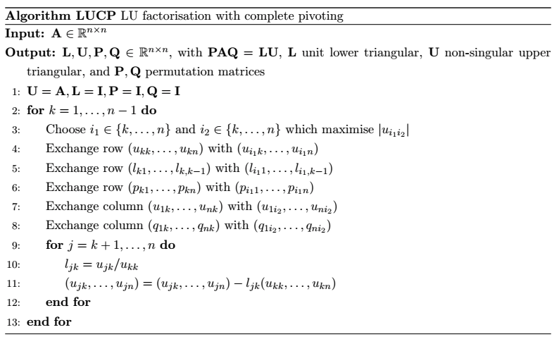

Note that the arithmetic operations in the double loop in lines 2 and 9-13 are exactly the same as in Algorithm LUPP (and Algorithm LU). The row swaps in lines 4-6 are also the same as in Algorithm LUPP. The novelty is in the selection of two pivots $i_1$ and $i_2$ in line 3 ($i_1$ for row swaps and $i_2$ for column swaps), and in the swaps of columns $k$ and $i_2$ in lines 7-8.

In line 3, you want to choose the pivots $i_1$ and $i_2$ so that $|u_{i_1i_2}| = \max_{k \leq i, j \leq n} |u_{ij}|$, i.e. $|u_{i_1i_2}|$ is the maximum element in the matrix

$$ \begin{bmatrix} |u_{kk}| & \dots &|u_{kn}| \\ \dots & \dots & \dots \\ |u_{nk}| & \dots &|u_{nn}| \end{bmatrix}.$$

### 1.1

In the code cell below, you are given a Python implementation of Algorithm LUPP, as already seen in the Week 5 computer labs.

Adapt this code (and the comments) so that it implements Algorithm LUCP.

Test your code on the small example given at the bottom of the code cell, for which the correct answer is

$$\mathbf{P} = \begin{bmatrix} 0 &0 &1 \\ 0 &1 &0 \\ 1 &0 &0 \end{bmatrix}, \; \mathbf{Q} = \begin{bmatrix} 0 &1 &0 \\ 0 &0 &1 \\ 1 &0 &0 \end{bmatrix}\; \mathbf{L} = \begin{bmatrix} 1 &0 &0 \\ \frac{3}{8} &1 &0 \\ \frac{1}{8}& \frac{5}{7} &1 \end{bmatrix} \approx \begin{bmatrix} 1 &0 &0 \\ 0.375 &1 &0 \\ 0.125& 0.71428571 &1 \end{bmatrix}, \;$$

$$\mathbf{U} = \begin{bmatrix} 8 &6 &7 \\ 0 &\frac{7}{4} &\frac{3}{8} \\ 0 &0 &-\frac{1}{7} \end{bmatrix} \approx \begin{bmatrix} 8 &6 &7 \\ 0 &1.75 &0.375 \\ 0 &0 &-0.14285714 \end{bmatrix}.$$

**[10 marks]**

```python
import numpy as np

#In this and
def LUCP(A):
    # Find dimension of A
    n = A.shape[0]

    #1: Initialise matrices L=I, U=A, P=I, Q=I
    L = np.eye(n)
    U = np.copy(A)
    P = np.eye(n)
    Q = np.eye(n)

    for k in range(n - 1): # 2: Loop over columns 1 to n-1

        # 3: Find pivot i
        '''Find position of maximum entry in matrix U (columns k to n, rows k to n)
        Use np function unravel_index which works like argmax but returns tuple
        for row and column index of max element in array'''
        # convert tuple to list in order to be able to amend elements
        i = list(np.unravel_index(np.abs(U[k:, k:]).argmax(), np.abs(U[k:, k:]).shape))

        # change indices in i as we are now in the kth iteration
        i[0] += k
        i[1] += k

        # 4-6: Swap rows
        if i[0] != k:
            # swap places of row i1 and k, columns k to n in U using tuple unpacking
            U[[k, i[0]], k:] = U[[i[0], k], k:]

            # swap places of row i1 and k, columns 1 to k-1 in L using tuple unpacking
            L[[k, i[0]], :k] = L[[i[0], k], :k]

            # swap places of row i1 and k in P using tuple unpacking
            P[[k, i[0]], :] = P[[i[0], k], :]

        # 7-8: Swap columns
        if i[1] != k:
            # swap places of column i2 and k in U using tuple unpacking
            U[:, [k, i[1]]] = U[:, [i[1], k]]

            # swap places of column i2 and k in Q using tuple unpacking
            Q[:, [k, i[1]]] = Q[:, [i[1], k]]

        # 9-11: Loop over rows and make entries below
        # diagonal in column k equal to 0
        for j in range(k + 1, n): # loop over rows k+1 to n
            L[j, k] = U[j, k] / U[k, k] # compute the multiplier L_jk
            U[j, k:] = U[j, k:] - L[j, k] * U[k, k:] # subtract a multiple of row k from row j in U

    return L, U, P, Q #Return amended matrices L,U,P,Q


# Test LUCP code on small example
A = np.array([[2, 1, 1], [4, 3, 3], [6, 7, 8]], dtype=float)
L, U, P, Q = LUCP(A) #run algorithm and assign names to outputs

#print outputs
print('L=\n', L)
print()
print('U=\n', U)
print()
print('P=\n', P)
print()
print('Q=\n', Q)
```

```
L=
 [[1.         0.         0.        ]
 [0.375      1.         0.        ]
 [0.125      0.71428571 1.        ]]

U=
 [[ 8.          6.          7.        ]
 [ 0.          1.75        0.375     ]
 [ 0.          0.         -0.14285714]]

P=
 [[0. 0. 1.]
 [0. 1. 0.]
 [1. 0. 0.]]

Q=
 [[0. 1. 0.]
 [0. 0. 1.]
 [1. 0. 0.]]
```

You may find the following code snippet useful, which returns the row and column index of the maximum element in a matrix ${\bf A}$.

```python
import numpy as np

# Small example to test on
A = np.array([[2, 1, 1], [4, 3, 3], [6, 7, 8]], dtype=float)
# Code to get location of maximum entry
index = np.unravel_index(np.argmax(A), A.shape)
# Check answer
print(index)
```

```
(2, 2)
```

### 1.2

The factorisation ${\bf PAQ} = {\bf LU}$ can now be used to solve the system of linear equations ${\bf A x} = {\bf b}$, as in the algorithm below:

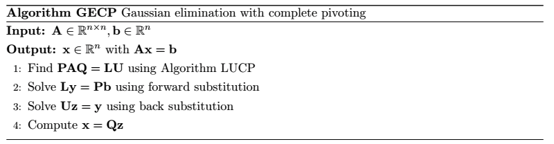

Implement Algorithm GECP in the code cell below.

Test your code on the small example given at the bottom of the code cell, to which the correct solution is $\mathbf{x} = [1,1,1]$.

*Even though this is computationally inefficient, for the purpose of this question you may compute $\mathbf{Pb}$ and $\mathbf{Qz}$ using the commands $\mathrm{P@b}$ and $\mathrm{Q@z}$.*

**[6 marks]**

```python
import numpy as np

# Define functions backsub and FS for back-/forward substitution as has
# been done in jp demo 2.2 and comp workshop 2
# These functions will be used in function GECP

def backsub(U,y):
    n=U.shape[0]
    x=np.zeros(n)

    for j in range(n-1,-1,-1):
        x[j] = (y[j] - U[j,j+1:] @ x[j+1:]) / U[j,j]

    return x

def FS(L, b):
    n = np.shape(L)[0]
    y = np.zeros(n)

    for i in range(n):
        y[i] = (b[i] - L[i, :i] @ y[:i]) / L[i, i]

    #return solution
    return y



# implement function GECP using the above functions backsub, FS, and LUCP
def GECP(A, b):

    #Step 1: run algorithm LUCP and assign names to outputs
    L, U, P, Q = LUCP(A)

    y = FS(L, P@b) # Step 2: solve for y in Ly=Pb using function FS since L lower triangular
    z = backsub(U, y) #Step 3: solve for z in Uz = y using function backsub since U upper triangular
    x = Q@z #compute solution x from Q and z

    #return solution
    return x

# Test the functions on a small example, the correct solution is x=[1,1,1]
A = np.array([[2, 1, 1], [4, 3, 3], [8, 7, 9]], dtype=float)
b = np.array([4, 10, 24], dtype=float)
x = GECP(A, b)

#Print solution. It corresponds to the correct answer
print('computed solution: x = {}'.format(x))
```

```
computed solution: x = [1. 1. 1.]
```

### 1.3

Investigate the performance of Algorithm GECP from Question 1.2 and that of Algorithm GEPP (as implemented in the code cell below) in terms of accuracy of the computed solution $\mathbf{\widehat x}$ and the time required to compute $\mathbf{\widehat x}$.

You should choose a suitable range of tests to run (which you think are important/insightful), implement these tests in the code cell below, display your results, and discuss and analyse your results in light of course material. Do you see any trends in the results? How do the algorithms compare? Are the results as expected from theory?

You may use without proof the following result on the backward stability of Algorithm GECP:

**Theorem 1** Let $\widehat{\mathbf{x}}$ be the computed solution to $ \mathbf A \mathbf x = \mathbf b$ by Algorithm GECP. Then

$$ \left( \mathbf{A} + \Delta\mathbf{A} \right)\widehat{\mathbf{x}} = \mathbf{b}, $$

where, with $p(n)$ the same cubic polynomial as in Theorem 2.9 from lectures,

$$ \| \Delta\mathbf{A} \|_{\infty} \leqslant p(n) \, n^{1/2} \, \sqrt{ \prod_{i=2}^n i^{1/(i-1)}} \, \varepsilon_m \, \| \mathbf{A} \|_{\infty}. $$

This theorem can be found for example in [this excellent review](https://www.maths.manchester.ac.uk/~higham/papers/high11g.pdf) on Gaussian elimination.

*If you are unsure what tests to run and how to analyse them, have a look at previous computer labs and Jupyter notebooks from lectures. What quantities do the computational time/cost and error depend on?*

**[25 marks]**

```python
# Implementation of Algorithm GEPP from Week 5 computer lab.

import numpy as np
# Using forwardsub and backsub from week 3.

def FS(L, b):
    # Find dimension of L
    n = L.shape[0]

    # Initialise y to zero vector of correct length
    y = np.zeros(n)

    # loop over elements of y, starting from first one
    for j in range(n):
        y[j] = (b[j] - L[j, :j] @ y[:j]) / L[j, j] # compute y_j

    return y

def BS(U, y):
    # Find dimension of U
    n = U.shape[0]

    # Initialise x to zero vector of correct length
    x = np.zeros(n)

    # loop over elements of x, starting from last one
    for j in range(n-1, -1, -1):
        x[j] = (y[j] - U[j, j+1:] @ x[j+1:]) / U[j, j] # compute x_j

    return x

# New implementation of Algorithm LUPP

def LUPP(A):
    # Find dimension of A
    n = A.shape[0]

    # Initialise matrices L=I, U=A, P=I
    L = np.eye(n)
    U = np.copy(A)
    P = np.eye(n)

    for k in range(n - 1): # Loop over columns 1 to n-1

        # Find pivot i
        i = np.argmax(np.abs(U[k:, k])) # Find position of maximum entry in required range
        i += k # Shift index to start counting from row 1

        # Swap rows correspondingly
        if i != k:
            # swap rows in U, columns k to n
            U[[k, i], k:] = U[[i, k], k:]

            # swap rows in L, columns 1 to k-1
            L[[k, i], :k] = L[[i, k], :k]

            # swap rows in P
            P[[k, i], :] = P[[i, k], :]

        # Loop over rows and make entries below
        # diagonal in column k equal to 0
        for j in range(k + 1, n): # loop over rows k+1 to n
            L[j, k] = U[j, k] / U[k, k] # compute the multiplier l_jk
            U[j, k:] = U[j, k:] - L[j, k] * U[k, k:] # subtract a multiple of row k from row j

    return L, U, P

def GEPP(A, b):
    L, U, P = LUPP(A) # find LU factorisation with permuation of A
    y = FS(L, P @ b) # solve Ly=Pb using forward substitution
    x = BS(U, y) # solve Ux=y using back substitution
    return x
```

**Tests**

For $n=10\times(2^i)$, $i\in \{0,1,2,3,4,5,6,7,8,9\}$ we first define a solution vector $\textbf{x} = [1,1,...,1] \in \mathbf{\rm I\!R}^n$. We then define a random matrix, $\textbf{A} \in \mathbf{\rm I\!R}^{nxn}$ (with entries according to uniform distribution on $[0,1)$) and a Hilbert matrix $\textbf{H} \in \mathbf{\rm I\!R}^{nxn}$, the latter of which is known to be of very ill-conditioned nature. Finally, we define vectors $\textbf{b} = \textbf{Ax}$, $\textbf{b}_H = \bf{Hx}$ and use GECP/GEPP to solve the systems $\textbf{Ax}=\textbf{b}$, $\textbf{Hx}=\textbf{b}_H$. Computation times, errors, and residuals of each algorithm are then assessed and compared in light of the course litterature.

```python
#Import some familiar libraries that will be useful for the tests
import time
import matplotlib.pyplot as plt
from scipy.linalg import hilbert

# Arrays that will contain computation times.
#Each array has two rows (random and hilbert) and 10 columns (matrix size)
GEPP_time = np.zeros((2,10))
GECP_time = np.zeros((2,10))

# We prepare here some arrays that will contain the inf-norm of the
# error (e) and residual (r) of GEPP and GECP. Again 2 rows and 10 columns as above.
eGEPP = np.zeros((2,10))
rGEPP = np.zeros((2,10))
eGECP = np.zeros((2,10))
rGECP = np.zeros((2,10))

for i in range(10): # Loop over matrix sizes
    n = 10*(2**i)
    A = np.random.rand(n,n) #random matrix of size n
    H = hilbert(n) #hilbert matrix of size n
    xsol = np.ones(n) #define known solution
    b = A @ xsol #define rhs of SLEs for random matrix
    bH = H @ xsol #likewise for the hilbert matrix

    # computation time for GEPP(A, b)
    t0 = time.time()
    xGEPPA = GEPP(A, b)
    t1 = time.time() - t0
    GEPP_time[0,i]=t1

    # computation time for GEPP(H, bH)
    t0 = time.time()
    xGEPPH = GEPP(H, bH)
    t1 = time.time() - t0
    GEPP_time[1,i]=t1

    # computation time for GECP(A, b)
    t0 = time.time()
    xGECPA = GECP(A, b)
    t1 = time.time() - t0
    GECP_time[0,i]=t1

    # computation time for GECP(H, bH)
    t0 = time.time()
    xGECPH = GECP(H, bH)
    t1 = time.time() - t0
    GECP_time[1,i]=t1

    # Compute inf-norm of residuals and errors for GEPP/GECP and add to relevant arrays
    eGEPP[0,i], rGEPP[0,i] = np.linalg.norm(xsol - xGEPPA, np.inf), np.linalg.norm(b - A@xGEPPA, np.inf)
    eGEPP[1,i], rGEPP[1,i] = np.linalg.norm(xsol - xGEPPH, np.inf), np.linalg.norm(bH - H@xGEPPH, np.inf)
    eGECP[0,i], rGECP[0,i] = np.linalg.norm(xsol - xGECPA, np.inf), np.linalg.norm(b - A@xGECPA, np.inf)
    eGECP[1,i], rGECP[1,i] = np.linalg.norm(xsol - xGECPH, np.inf), np.linalg.norm(bH - H@xGECPH, np.inf)
```

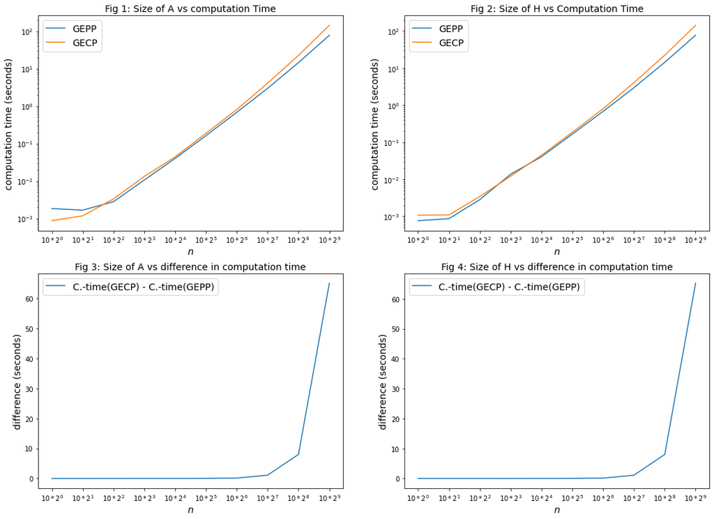

```python
#Set up plots to investigate computation times of GEPP and GECP on matrices A and H of different sizes
fig, ax = plt.subplots(2,2, figsize=(18,13))

# Make some titles to be used in plots
tit1 = ['Fig 1: Size of A vs computation Time', 'Fig 2: Size of H vs Computation Time']
tit2 = ['Fig 3: Size of A vs difference in computation time', 'Fig 4: Size of H vs difference in computation time']

#Plot the computation times for GEPP and GECP side-by-side
for i in [0,1]:
    ax[0,i].plot([10*(2**i) for i in range(10)], GEPP_time[i], label = 'GEPP')
    ax[0,i].plot([10*(2**i) for i in range(10)], GECP_time[i], label = 'GECP')
    ax[0,i].set_yscale('log', base=10) #scale y-axis according to powers of 10 for easier interpretation
    ax[0,i].set_xscale('log', base=2) #scale x-axis according to step-size in n
    ax[0,i].set_xticks([10,20,40,80,160,320,640,1280, 2560, 5120]) #set ticks on x-axis
    ax[0,i].set_xticklabels([r'$10*2^0$','$10*2^1$','$10*2^2$','$10*2^3$','$10*2^4$','$10*2^5$','$10*2^6$',\
                             '$10*2^7$', '$10*2^8$', '$10*2^9$'])
    ax[0,i].set_xlabel(r'$n$', fontsize=14)
    ax[0,i].set_ylabel('computation time (seconds)', fontsize=14) #y-axis label
    ax[0,i].legend(loc='upper left', fontsize=14) #Add a legend that will help explain each plot
    ax[0,i].set_title(tit1[i], fontsize=14) #set title

#Plot computation time of GECP minus computation time of GEPP
for i in [0,1]:
    ax[1,i].plot([10*(2**i) for i in range(10)], GECP_time[i]-GEPP_time[i], label = 'C.-time(GECP) - C.-time(GEPP)')
    ax[1,i].set_xscale('log', base=2) #scale only x-axis here in order to demonstrate absolute differences on y-axis
    ax[1,i].set_xticks([10,20,40,80,160,320,640,1280, 2560, 5120])
    ax[1,i].set_xticklabels([r'$10*2^0$','$10*2^1$','$10*2^2$','$10*2^3$','$10*2^4$','$10*2^5$','$10*2^6$',\
                             '$10*2^7$', '$10*2^8$', '$10*2^9$'])
    ax[1,i].set_xlabel(r'$n$', fontsize=14)
    ax[1,i].set_ylabel('difference (seconds)', fontsize=14)
    ax[1,i].legend(loc='upper left', fontsize=14)
    ax[1,i].set_title(tit2[i], fontsize=14)

plt.show()#show plots
```

[figure not shown]

```python
#Set up plots to investigate difference in errors and residuals of GEPP and GECP on matrices A
#and H of different sizes
fig, ax = plt.subplots(2,2, figsize=(18,13))

# Make some titles to be used in plots
tit1 = [r'Fig 5: Error-norm $||\bf{x}-\bf{\hat{x}}||_\infty$ for computed solution' + \
        r'$\bf{\hat{x}}$ to $\bf{Ax}=\bf{b}$',
        r'Fig 6: Error-norm $||\bf{x}-\bf{\hat{x}}||_\infty$ for computed solution $\bf{\hat{x}}$ to $\bf{Hx}={b_H}$']
tit2 = [r'Fig 7: Residual-norm $||\bf{b}-\bf{A}\hat{\bf{x}}||_\infty$ for computed solution' + \
        r'$\bf{\hat{x}}$ to $\bf{Ax}=\bf{b}$',
        r'Fig 8: Residual-norm $||\bf{b_H}-\bf{H}\hat{\bf{x}}||_\infty$ for computed solution' + \
        r'$\bf{\hat{x}}$ to $\bf{Hx}=\bf{b_H}$']


#plot (relative) error for GEPP and GECP on random matrix A and hilbert matrix H
for i in [0,1]:
    ax[0,i].plot([10*(2**i) for i in range(10)], eGEPP[i], label = 'GEPP')
    ax[0,i].plot([10*(2**i) for i in range(10)], eGECP[i], label = 'GECP')
    ax[0,i].set_yscale('log', base=10) #scale y-axis according to powers of 10 for easier interpretation
    ax[0,i].set_xscale('log', base=2) #scale x-axis according to step-size in n
    ax[0,i].set_xticks([10,20,40,80,160,320,640,1280, 2560, 5120])
    ax[0,i].set_xticklabels([r'$10*2^0$','$10*2^1$','$10*2^2$','$10*2^3$','$10*2^4$','$10*2^5$','$10*2^6$',\
                             '$10*2^6$', '$10*2^7$', '$10*2^8$'])
    ax[0,i].set_xlabel(r'$n$', fontsize=14)
    ax[0,i].set_ylabel(r'$||\bf{x}-\bf{\hat{x}}||_\infty$', fontsize=14)
    ax[0,i].legend(loc='upper left', fontsize=14)
    ax[0,i].set_title(tit1[i], fontsize=14)

#Likewise for residuals
for i in [0,1]:
    ax[1,i].plot([10*(2**i) for i in range(10)], rGEPP[i], label = 'GEPP')
    ax[1,i].plot([10*(2**i) for i in range(10)], rGECP[i], label = 'GECP')
    ax[1,i].set_yscale('log', base=10)
    ax[1,i].set_xscale('log', base=2)
    ax[1,i].set_xticks([10,20,40,80,160,320,640,1280, 2560, 5120])
    ax[1,i].set_xticklabels([r'$10*2^0$','$10*2^1$','$10*2^2$','$10*2^3$','$10*2^4$','$10*2^5$','$10*2^6$'\
                             ,'$10*2^6$', '$10*2^7$', '$10*2^8$'])
    ax[1,i].set_xlabel(r'$n$', fontsize=14)
    if i == 0:
        ax[1,i].set_ylabel(r'$||\bf{b}-\bf{A}\hat{\bf{x}}||_\infty$', fontsize=14)
    if i==1:
        ax[1,i].set_ylabel(r'$||\bf{b_H}-\bf{H}\hat{\bf{x}}||_\infty$', fontsize=14)

    ax[1,i].legend(loc='upper left', fontsize=14)
    ax[1,i].set_title(tit2[i], fontsize=14)

plt.show() #show plots
```

**Discussion for Q1.3** $\newline$ **Computational Cost** $\newline$ We know that the computational cost of GEPP is $$C(n) = \frac{2}{3}n^3+3n^2-\frac{5}{3}n.$$ The cost of finding the pivot for each $k \in (1,2,...,n-1)$ of LUCP will be $(n-k+1)^2$ for a total of $$\sum_{k=1}^{n-1}(n-k+1)^2=\frac{n^3}{3}+\frac{n^2}{2}+\frac{n}{6}-1.$$ Algorithm GECP has the same number of FLOPS as GE in addition to finding the complete pivots under LUCP and the multiplaction $\textbf{Qz}$ in line 4. As we know from algorithm MV, the latter has a computational cost of $C(n)=2n^2$. Disregarding the constant of $-1$, it follows that the computational cost of GECP will be $$C(n) = \frac{2}{3}n^3+\frac{5}{2}n^2-\frac{7}{6}n + \frac{n^3}{3}+\frac{n^2}{2}+\frac{n}{6} + 2n^2 = n^3 + 5n^2 -n = O(n^3),$$ where we have assumed that row swaps do not count as FLOPs. As expected from the formulae for computational cost, computational times for GEPP and GECP grow log-linearly as functions of matrix dimension $n$ of square random matrix $\textbf{A}$ and Hilbert matrix $\textbf{H}$ (figures 1 and 2). The difference in computation cost for GECP and GEPP is seen to be $$C(n)_{GECP} - C(n)_{GEPP} = \frac{n^3}{3} + 2n^2 + \frac{2n}{3} = O(n^3).$$ This difference in computation time matches well with the experiemental results seen in figures 3 and 4, where we see that for growing $n$, computation time of GECP grows exponentially faster than that of GEPP. Furthermore, the difference in computation times is on the order of the computation time for GEPP itself, meaning that it is very much non-negligible. As is expected, computation times for the random- and Hilbert matrices of dimension $n \times n$ are almost identical for each algorithm, $\textbf{respectively}$, due to the fixed number of FLOPS for a given matrix dimension.

**Errors and Residuals** $\newline$ When analysing the accuracy of algorithms, it makes sense to investigate the $\infty$-norm since this gives the largest entry-wise error (residual) of a solution $\hat{\textbf{x}}$. For a system $\textbf{Bx}=\bf{b}$, $\mathbf{B} \in \mathbf{\rm I\!R}^{n \times n}$, it would be useful to compare the $\infty$-norm of the perturbation matrices $||\Delta \mathbf{B}||_\infty^{GEPP}$ and $||\Delta \mathbf{B}||_\infty^{GECP}$ in order to pick the method that has the smallest upper bound on relative error (as per 2.11 in notes). As noted in the review by NJ. Higham mentioned above,

$$\, n^{1/2} \, \sqrt{ \prod_{i=2}^n i^{1/(i-1)}} \, \approx c n^{\frac{2+ln(n)}{4}},$$

for some $c \in \mathbf{\rm I\!R}$ (Higham, 2011). From this, we easily see that the upper bound of $||\Delta \mathbf{B}||_\infty^{GEPP}$, as given in theorem 2.9 of the notes, grows much faster than the upper bound of $||\Delta \mathbf{B}||_\infty^{GECP}$ for increasing $n$. However, these bounds are are often large overestimates of $||\Delta \mathbf{B}||_\infty^{GEPP}$, $||\Delta \mathbf{B}||_\infty^{GECP}$ (Higham, 2011). It was long though that

$$||\Delta \mathbf{B}||_\infty^{GECP} \leq p(n)\rho_n\varepsilon_m ||\mathbf{B}||_\infty, \hspace{1em} \rho_n \leq n, \hspace{1em} \forall \mathbf{B} \in \mathbf{\rm I\!R}^{n \times n}, \text{non-singular}.$$

Although this conjecture was disproven in 1991, its longevity attests to the rarity of matrices for which $\rho_n > n$ (Higham, 2011). Furthermore, we know from the notes that $||\Delta \mathbf{B}||_\infty^{GEPP}\approx \varepsilon_m \sqrt{n} ||\mathbf{A}||_\infty$ for most matrices $\mathbf{B} \in \mathbf{\rm I\!R}^{n \times n}.$ We thus expect the difference $||\Delta \mathbf{B}||_\infty^{GEPP} - ||\Delta \mathbf{B}||_\infty^{GECP}$ to be much smaller than may be implied by their upper bounds. This, in turn would mean smaller differences in the upper bounds on relative error, as may be deduced from 2.11. However, the lack of tight ubiquitous bounds on $||\Delta \mathbf{B}||_\infty^{GEPP}$ and $||\Delta \mathbf{B}||_\infty^{GECP}$ make it difficult to theoretically analyse the errors of GECP and GEPP a priori here. We are thus left to test their performance computationally.

Figures 5 and 6 show that the error-norms of GECP and GEPP are very similar across all values of $n$. The same holds true for the residual-norms (figures 7 and 8), indicating that algorithms GEPP and GECP have very similar levels of accuracy. In particular, the error- and residual-norms of GECP is not uniformly lower than those of GEPP accross all $n$. This (very small) set of tests confirm what we have learnt in the lectures: the high computational cost of GECP far outweighs any benefit in accuracy, compared to GEPP. This is even the case for the very ill-conditioned Hilbert matrices, for which the error-norm becomes very large for large $n$. (As seen in week 3, the residual when computing with the Hilbert matrix remains small since it does not involve multiplication with $\mathbf{H}^{-1}$, which has very large $\infty$-norm.

**References** $\newline$ Higham, N. J. (2011). Gaussian elimination. Wiley Interdisciplinary Reviews: Computational Statistics, 3(3), 230–238. https://doi.org/10.1002/wics.164

# Question 2

In this question, we want to develop a version of *iterative refinement* (as seen in the Week 5 computer lab) for iterative methods for solving $ \mathbf A \mathbf x = \mathbf b$.

The main steps in iterative refinement for Gaussian elimination were as follows:

1. Solve $\mathbf A \mathbf x = \mathbf b$ with Gaussian elimination, to obtain computed solution $\widehat{\mathbf{x}}$
2. Compute the residual $\mathbf r = \mathbf b - \mathbf{A}\widehat{\mathbf x}$
3. Solve $\mathbf{Ae} = \mathbf r$ with Gaussian elimination, to obtain computed solution $\widehat{\mathbf{e}}$
4. Update $\widehat {\mathbf x} = \widehat{\mathbf x} + \widehat{\mathbf e}$.

In step 4, we are using the fact that the error $\mathbf e = \mathbf x - \widehat{\mathbf x}$ in the computed solution $\widehat{\mathbf x}$ satisfies $\mathbf A \mathbf e = \mathbf A \mathbf x - \mathbf A \widehat{\mathbf x} = \mathbf b - \mathbf A \widehat{\mathbf x} = \mathbf r$. The solve in step 3 can be done cheaply, in $\mathcal O(n^2)$ cost, since we can re-use the LU factorisation that was already computed in step 1. So the additional cost of adding steps 2-4 is negligible, but they significantly increase the accuracy of the computed solution.

For iterative methods, such as the Jacobi and Gauss-Seidel methods, both solves in steps 1 and 3 would have $\mathcal O(n^2)$ cost, and so the "refinement" steps 2-4 would substantially increase the cost. To reduce the cost, we want to solve a *smaller* system in step 3. Let's see how that's done.

For the remainder of this question, assume $\mathbf A \in \mathbb R^{(2\ell-1) \times (2 \ell-1)}$, for some $\ell \in \mathbb N$.

For $\ell \in \mathbb{N}$, define a restriction operator ${rest} : \mathbb{R}^{2\ell-1} \rightarrow \mathbb{R}^{\ell-1}$ by

$$ (rest(\mathbf v))_i = \frac{1}{4} ( v_{2i-1} + 2 v_{2i} + v_{2i+1}), \quad \forall i=1, \dots, \ell-1, $$

for all $\mathbf v \in \mathbb{R}^{2\ell-1}$. Similarly, define a prolongation operator $prol : \mathbb{R}^{\ell-1} \rightarrow \mathbb{R}^{2\ell-1}$ by

$$ (prol(\mathbf z))_i = \begin{cases} z_{i/2} & \textrm{if } i \textrm{ is even, } \\ \frac{1}{2}( z_{(i-1)/2} + z_{(i+1)/2}) & \textrm{if } i \textrm{ is odd }, i \neq 1, i \neq 2\ell-1, \\ \frac{1}{2}( z_{(i+1)/2}) & \textrm{if } i = 1, \\ \frac{1}{2}( z_{(i-1)/2}) & \textrm{if } i = 2\ell-1, \end{cases}, \quad \forall i=1, \dots, 2\ell-1, $$

for all $\mathbf z \in \mathbb{R}^{\ell-1}$.

These operators are implemented in the code cell below.

```python
import numpy as np

def rest(v):

    # Initialise rest(v) to zero vector of correct length
    l = int((len(v)+1)/2-1)
    r_v = np.zeros(l)

    # Compute entries in rest(v)
    for j in range(l):

        r_v[j] = (v[2*(j+1)-2] + 2*v[2*(j+1)-1] + v[2*(j+1)])/4 # implement given formula

    return r_v

def prol(z):

    # Initialise prol(z) to zero vector of correct length
    l = len(z)+1
    p_z = np.zeros(2*l-1)

    # Compute entries in prol(z)

    # First and last entry given separately
    p_z[0] = z[0]/2
    p_z[2*l-2] = z[l-2]/2

    # Other entries given by general formula
    for j in range(1,2*l-2):

        #If j is even (corresponds to odd indices i in practice)
        if j % 2 ==0:

            p_z[j] = (z[int(j/2-1)] + z[int((j+2)/2-1)])/2 # implement given formula

        # If j is odd (corresponds to even indices i in practice)
        else:

            p_z[j] = z[int((j+1)/2-1)] # implement given formula

    return p_z

# Small example to test what the operators are doing
v = np.array([1,2,1,2,1], dtype=float)
print(rest(v))
z = np.array([1.5, 1.5], dtype=float)
print(prol(z))
```

```
[1.5 1.5]
[0.75 1.5  1.5  1.5  0.75]
```

### Question 2.1

Denote by $\mathbf e_k = \mathbf x - \mathbf x_k$ the error and $\mathbf r_k = \mathbf b - \mathbf{Ax}_k$ the residual after the $k$th iteration of the Gauss-Seidel method.

The operators $rest$ and $prol$ introduced above are linear, and so can be represented by matrices $\mathbf R \in \mathbb R^{(\ell-1) \times (2\ell-1)}$ and $\mathbf P \in \mathbb R^{(2\ell-1) \times (\ell-1)}$, respectively, i.e. $rest(\mathbf v) = \mathbf{Rv}$ and $prol(\mathbf z) = \mathbf{Pz}$.

Assuming $\mathbf e_k = \mathbf {P R e}_k$, show that

$$ \mathbf{A}_R (\mathbf{R e}_k) = \mathbf{R r}_k, $$

where $\mathbf {A}_R = \mathbf{R A P} \in \mathbb R^{(\ell-1) \times (\ell-1)}$.

**[4 marks]**

**Answer for Q2.1**

Note first that $\mathbf{A}\mathbf{e}_k = \mathbf{Ax} - \mathbf{A}\mathbf{x}_k = \mathbf{b} - \mathbf{A}\mathbf{x}_k = \mathbf{r}_k$. Since $\mathbf A \in \mathbb R^{(2\ell-1) \times (2 \ell-1)}$ we know also $\mathbf{r}_k \in \mathbb R^{(2\ell-1) \times 1}$. Left-multiplying by $\mathbf{R}$ on both sides yields,

$$ \mathbf{RA}\mathbf{e}_k = \mathbf{R}\mathbf{r}_k $$

Then using the property $\mathbf e_k = \mathbf {P R e}_k$, we get $$ \mathbf{A}_R(\mathbf{R}\mathbf{e}_k) = \mathbf{RAPR}\mathbf{e}_k = \mathbf{RA}(\mathbf{PR}\mathbf{e}_k) = \mathbf{RA}\mathbf{e}_k $$ Hence, $\mathbf{A}_R(\mathbf{R}\mathbf{e}_k) = \mathbf{R}\mathbf{r}_k$

### Question 2.2

Consider the following version of the Gauss-Seidel method, which stops the iteration after a prescribed number of iterations $k_*$ have been performed:

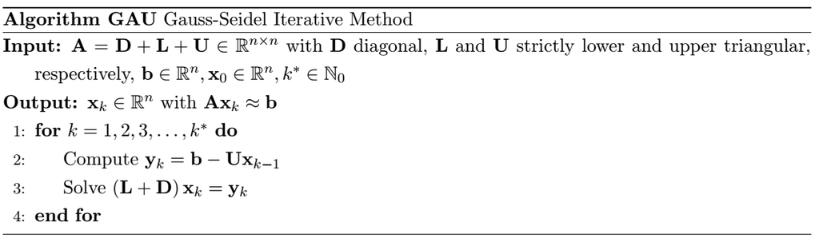

Implement this algorithm in the code cell below. You may find the functions `np.triu` and/or `np.tril` helpful, and you may also want to re-use some code from the implementation of the Jacobi method found in the Wee6 Jupyter notebook from lectures.

Test your code on the small example given at the bottom of the code cell, for which the correct answer is $\mathbf x_2 = [9/8, 15/16] = [1.125, 0.9375]$.

**[12 marks]**

```python
import numpy as np

#Define Forward substitution, FS, as done in jupyter notebook 2.2
def FS(L, b):
    n = np.shape(L)[0]
    y = np.zeros(n)

    for i in range(n):
        y[i] = (b[i] - L[i, :i] @ y[:i]) / L[i, i]

    #return solution
    return y

#Define efficient function to compute matrix-vector
#product of strictly upper triangular U with vector v
#(based on algorithm page 39 in notes)
def Uv(U, v):
    #Set up array of zeros that will contain result
    #Length needs to be equal to "height" of U
    n = U.shape[0]
    Uv = np.zeros(n)

    # loop over 1,...,n and assign values to
    # elements in Uv according to a sum
    # over (U)_(ij)*v_j for j=i+1,...,j=n
    for i in range(n):
        Uv[i] = U[i, i+1:]@v[i+1:]

    return Uv #return array


#implement algorithm Gauss-Seidel
def gauss_seidel(A, b, x0, k_star):

    # First find D using np.diag as in week 6 notebook
    D = np.diag(np.diag(A))

    #Find L+D and U using D from above
    #(must subtract diagonal since this not done in functions np.triu, np.tril)
    LplusD = np.tril(A)
    U = np.triu(A) - D

    #initiate x_k to x_0
    xk = x0


    #1: Do k* iterations
    for k in range(k_star):

        #2: computation y_k = b - Ux_(k-1)
        yk = b - Uv(U, xk)

        #3: Solve system in line 3 for x_k using forward substitution as in notes
        xk = FS(LplusD, yk)

    return xk

# Test code on small example
A = np.array([[2,1],[1,2]], dtype=float)
b = np.array([3,3], dtype=float)
x0 = np.array([0,0], dtype=float)
k_star = 2
x2 = gauss_seidel(A, b, x0, k_star)
print(x2)
```

```
[1.125  0.9375]
```

### Question 2.3

Consider the particular $\mathbf A$, $\mathbf b$ and $\mathbf x_0$ set up in the code cell below.

Compute the residual $\mathbf r_k$ for the Gauss-Seidel method, for $k=1,2,3,5,10,20$, and plot these residuals in separate plots. (In your plots, you want to plot $\mathbf r_k \in \mathbb R^n$ against the vector $[1,2,3,\dots, n]$.) What trends do you observe as $k$ increases?

**[5 marks]**

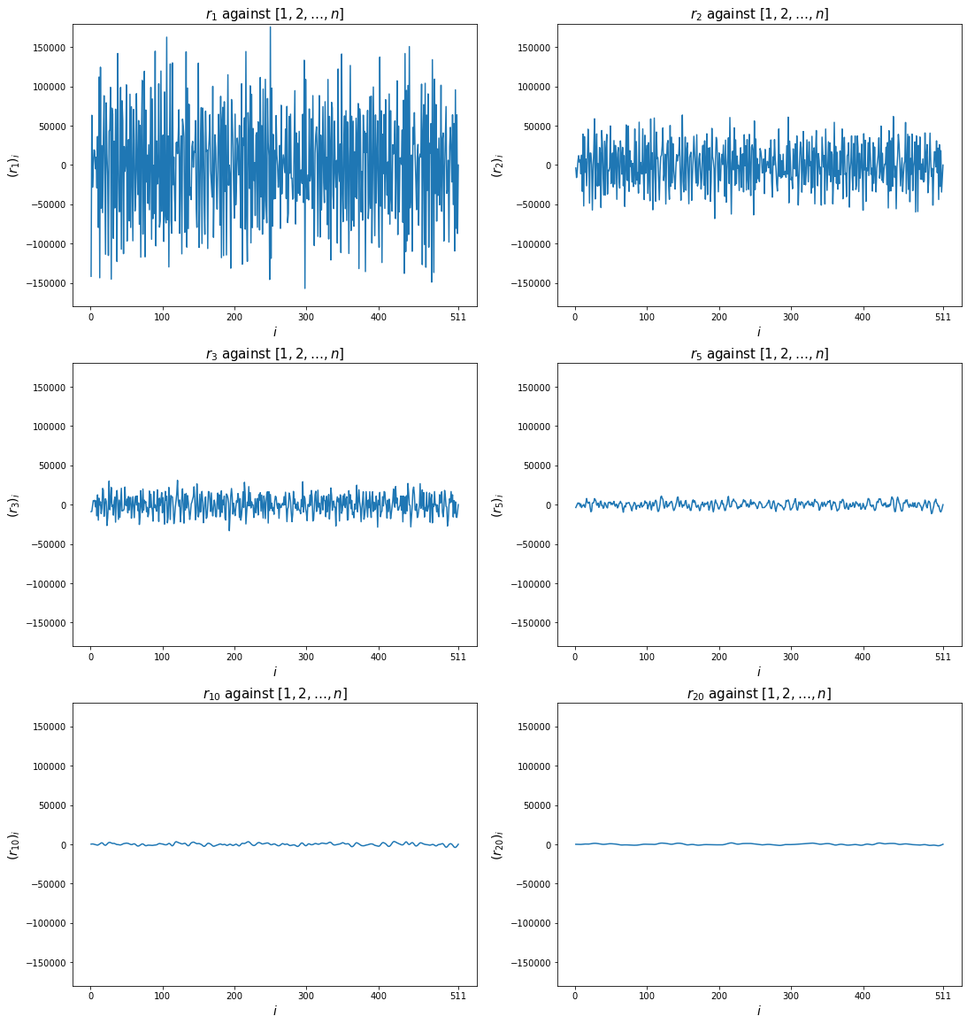

```python
import numpy as np

# Set up the matrix A and right-hand side vector b
n = 511
A = (n+1)**2*(np.diag(2*np.ones(n),k=0) + np.diag(-np.ones(n-1),k=1) + np.diag(-np.ones(n-1),k=-1))
y = np.linspace(1/(n+1), n/(n+1),n)
b = 100*np.pi**2*np.sin(10*np.pi*y) + 10*np.ones(n)
# Choose a random starting guess
np.random.seed(1) # fix the seed so that everyone gets the same random starting guess
x0 = np.random.rand(n)

#List of k-values
k_list = [1,2,3,5,10,20]

#Set up figure to plot residual rk for each k
fig, ax = plt.subplots(3,2, figsize=(18,20))

#Loop over ks and run gauss_seidel, simultaneously plotting rk for each k
for j in range(6):
    #Directly compute residual
    rj = b - A@gauss_seidel(A,b,x0,k_list[j])

    #plot residual rk against [1,2,...,n] = y * (n+1)
    ax[j//2, j%2].plot(y*(n+1), rj)
    ax[j//2, j%2].set_xticks([0, 100, 200, 300, 400, 511]) #set ticks on x-axis
    ax[j//2, j%2].set_xlabel(r'$i$', fontsize=14) #set label of x-axis
    ax[j//2, j%2].set_ylabel(fr'$(r_{{{k_list[j]}}})_i$', fontsize=14) #set label of y-axis
    ax[j//2, j%2].set_title(fr'$r_{{{k_list[j]}}}$ against $[1,2,\dots,n]$', fontsize=15) #set title
    ax[j//2, j%2].set_ylim([-180000, 180000]) #fix limits of y-axis to better compare r_k for different k

plt.show() #show plots
```

### 2.4

Consider the following algorithm as a version of iterative refinement for the Gauss-Seidel method:

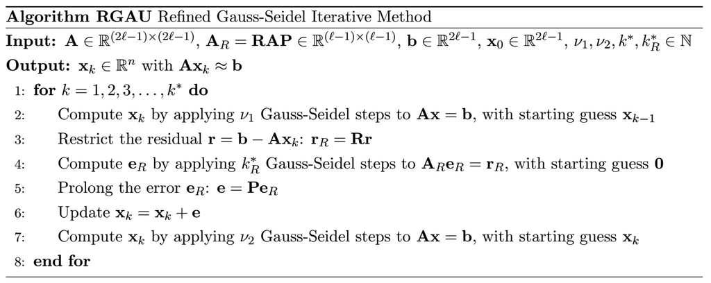

Here, the restriction and prolongation matrices $\mathbf R \in \mathbb R^{(\ell-1) \times (2\ell-1)}$ and $\mathbf P \in \mathbb R^{(2\ell-1) \times (\ell-1)}$ are as defined in Question 2.1. You can compute $\mathbf {R r}$ and $\mathbf {P e}_R$ using the Python functions 'rest' and 'prol' given at the beginning of this question.

Implement this algorithm in the code cell below.

Test your code on the example given at the bottom of the code cell, which is the same as in Question 2.3. For both methods, you should observe that the relative residual norm is around $0.005$ (I obtained $0.0049862565176693385$ for standard Gauss-Seidel and $0.004955784157255719$ for refined Gauss-Seidel, but your results will vary slightly depending on implementation and which machine it is run on).

You should note that refined Gauss-Seidel is much faster than standard Gauss-Seidel!

*For debugging purposes, you may want to change the value of n. But remember to change it back to n=511 in the end!*

**[10 marks]**

```python
import numpy as np

def r_gauss_seidel(A,b,x0,A_R,nu1,nu2,k_star,kR_star):

    #define xk
    xk = x0

    for k in range(k_star): #1: Loop over elements 1,...,k*

        #2: compute xk with nu1 GS steps
        xk = gauss_seidel(A, b, xk, nu1)

        #3: restrict residual
        rR = rest(b - A@xk)

        #4: compute eR using kR* GS steps (starting guess: zero vector of dimension l-1=(n-1)/2)
        eR = gauss_seidel(A_R, rR, np.zeros(int((n-1)/2)), kR_star)

        #5: prolong error eR
        e = prol(eR)

        #6: update xk
        xk += e

        #7: compute xk by applying nu2 Gauss-Seidel steps to Ax = b (starting guess xk)
        xk = gauss_seidel(A, b, xk, nu2)

    return xk

# Test on particular example
import time

# Set up the matrix A and right-hand side vector b
n = 511
A = (n+1)**2*(np.diag(2*np.ones(n),k=0) + np.diag(-np.ones(n-1),k=1) + np.diag(-np.ones(n-1),k=-1))
y = np.linspace(1/(n+1), n/(n+1),n)
b = 100*np.pi**2*np.sin(10*np.pi*y) + 10*np.ones(n)

# Set up corresponding matrix A_R = R A P
m = int((n+1)/2 - 1)
A_R = (m+1)**2*(np.diag(2*np.ones(m),k=0) + np.diag(-np.ones(m-1),k=1) + np.diag(-np.ones(m-1),k=-1))

# Choose a random starting guess
np.random.seed(1) # fix the seed so that everyone gets the same random starting guess
x0 = np.random.rand(n)

# Compute solution using standard Gauss-Seidel, and compute relative residual of computed solution
k_star = 7100
t0 = time.time()
xk1 = gauss_seidel(A, b, x0, k_star)
t1 = time.time() - t0
rk1 = np.linalg.norm(A@xk1 - b)/np.linalg.norm(b)
print('For standard Gauss-Seidel, the residual is = {0}, and the computation time was {1:.2} seconds\n'\
      .format(rk1, t1))
# Compute solution using refined Gauss-Seidel, and compute relative residual of computed solution
nu1 = 3
nu2 = 3
k_star = 3
kR_star = 600
t0 = time.time()
xk2 = r_gauss_seidel(A,b,x0,A_R,nu1,nu2,k_star,kR_star)
t2 = time.time() - t0
rk2 = np.linalg.norm(A@xk2 - b)/np.linalg.norm(b)
print('For refined Gauss-Seidel, the residual is = {0}, and the computation time was {1:.2} seconds\n'\
      .format(rk2, t2))
```

```
For standard Gauss-Seidel, the residual is = 0.004986256517669339, and the computation time was 9.3 seconds

For refined Gauss-Seidel, the residual is = 0.00495578415725572, and the computation time was 1.2 seconds
```

### Question 2.5

Explain how the idea in Algorithm RGAU can be applied recursively to further reduce the computational cost of solving $\mathbf {Ax} = \mathbf b$. (This is reminiscent of the *divide-and-conquer* strategy seen in the Week 3 computer lab.)

You can write down pseudo-code, or carefully explain your algorithm in words. You do not need to implement your algorithm in Python.

What restrictions are there on the size of the matrix $\mathbf A$? What is your base case in the recursion? How would you choose the number of steps/iterations in the different parts of your code (a general qualitative statement is fine here)?

**[10 marks]**

**Answer to Q2.5**

Below is the pseudo-code for Algorithm RGAU applied recursively. This algorithm rests on $\mathbf{A}$ having dimension $(2\ell-1) \times (2\ell-1)$, where $\ell$ is a power of 2, and being able to compute $\mathbf{R}\mathbf{A}_R\mathbf{P}$ each time the function calls itself.

**Algorithm RERGAU (Recursive Refined Gauss-Seidel Iterative Method)** $\newline$ **Input:** $\mathbf{A} \in \mathbb{R}^{(2\ell -1)\times (2\ell -1)}$ non-singular, $\mathbf{A}_R = \mathbf{RAP} \in \mathbb{R}^{(\ell -1) \times (\ell -1)}, \mathbf{b} \in \mathbb{R}^{(2\ell -1)\times (2\ell -1)}, \mathbf{x}_0 \in \mathbb{R}^{(2\ell -1)\times (2\ell -1)}, \nu_1, \nu_2, k^* \in \mathbb{N}$

**Output:** $\mathbf{x}_k \in \mathbb{R}^{2\ell -1}$ with $\mathbf{A}\mathbf{x}_k \approx \mathbf{b}$

1. $\textbf{if} \hspace{0.5em} A \in \mathbb{R}^{1\times 1} \hspace{0.5em} \textbf{do}$
2. $\hspace{1em} \mathbf{x}_1=\mathbf{b}/a_{11}$ $\newline$
3. $\textbf{if} \hspace{0.5em} A \notin \mathbb{R}^{1\times 1} \hspace{0.5em} \textbf{do}$
4. $\hspace{1em}$Compute $\mathbf(A_R)_R=\mathbf{R(RAP)P}$
5. $\hspace{1em} \textbf{for} \hspace{0.5em} k = 1,2,...,k^{*} \hspace{0.5em} \textbf{do}$
6. $\hspace{2em}$ Compute $\mathbf{x}_k$ by applying $\nu_1$ Gauss-Seidel steps to $\mathbf{Ax}=\mathbf{b}$, with starting guess $\mathbf{x}_{k-1}$
7. $\hspace{2em}$ Restrict the residual: $\mathbf{r} = \mathbf{b} - \mathbf{A}\mathbf{x}_k: \mathbf{r}_R = \mathbf{Rr}$
8. $\hspace{2em}$ Compute $\mathbf{e}_R$ using RERGAU($\mathbf{A}_R, (\mathbf{A}_R)_R,\mathbf{r}_R, \mathbf{0}, \nu_1, \nu_2, k^*)$
9. $\hspace{2em}$ Prolong the error $\mathbf{e}_R: \mathbf{e} = \mathbf{P}\mathbf{e}_R$
10. $\hspace{2em}$ Update $\mathbf{x}_k = \mathbf{x}_k + \mathbf{e}$
11. $\hspace{2em}$ Compute $\mathbf{x}_k$ by applying $\nu_2$ Gauss-Seidel steps to $\mathbf{Ax}=\mathbf{b}$, with starting guess $\mathbf{x}_{k}$

Note that due to what we know about computational cost of Gauss-Seidel from notes, Algorithm RGAU has a computational cost of $\nu_1(2n^2+2n)$ in line 2 of each iteration. By what we know of Algorithm MV and simple subtraction, RGAU has cost $3n^2$ in each iteration of line 3. Similarly it has a cost of $k_R^*((n-1)^2+(n-1))$ in line 4. Line 5 has a computational cost of $n(n-1)$, whereas line 6 has computational cost $n$. Finally, line 7 has computational cost $\nu_2(2n^2+2n)$. The total computational cost of RGAU is then $\newline$ $$ C(n) = k^*((2\nu_1 +2 \nu_2 +4 + k_R^*)n^2 + (2\nu_1 +2\nu_2 -k_R^*)n) = O(n^2) $$ Importantly, we see that $k^*k_R^*$ are in the coefficient for $n^2$. If we presume that $k_R^*, k^*$ are chosen large compared to $\nu_1, \nu_2$, as in the code example above, $k^*k_R^*n^2$ will determine most of the computational cost of the problem. Algorithm RERGAU sidesteps the need for a term $k_R^*$ entirely, instead calling itself in order to compute $\mathbf{e}_R$ as a series of smaller problems. The recursion deepens until the system to be solved has a single unknown variable, which can be found by a single division. The base case in the recursion is thus $\mathbf{A} \in \mathbb{R}^{1\times 1}$. $\newline$ Note that each time RERGAU calls itself, the system to be solved has been reduced in size. This reduction in size will occurr a total of $log_2(n+1)-1$ times (i.e. we must compute a new $\mathbf{R}(\mathbf{A}_R)\mathbf{P}$ a total of $log_2(n+1)-1$ times). Implementing RERGAU, the values I choose for $\nu_1, \nu_2, k^*$ would depend on the size of the norms $||\mathbf{-D}^{-1}(\mathbf{L}+\mathbf{U})||_\infty$ $\textit{across all the matrices}$ $$\{\mathbf{A}, \mathbf{RAP}, \mathbf{RRAPP}, \dots, \mathbf{R}^{log_2(n+1)-1}\mathbf{A}\mathbf{P}^{log_2(n+1)-1}\} .$$ Let $\hat{\mathbf{e}}_0$ be the error (of the sub-problem passed to RERGAU) when line 5 in a particular iteration is encountered. By Theorem 3.1 in notes, we would have $$||\mathbf{e}||_\infty \leq ||\mathbf{-D}^{-1}(\mathbf{L}+\mathbf{U})||_\infty^{\nu_1}||\mathbf{e}_0||_\infty$$ after line 5 completed. Likewise, let $\bar{\mathbf{e}}_0$ be the error (of the particular subproblem) when line 11 in a particular iteration is encountered. After completion of line 11 we would have $$||\mathbf{e}||_\infty \leq||\mathbf{-D}^{-1}(\mathbf{L}+\mathbf{U})||_\infty^{\nu_2}||\mathbf{e}_0||_\infty.$$ If $||\mathbf{-D}^{-1}(\mathbf{L}+\mathbf{U})||_\infty$ was small for many of the matrices $$\{\mathbf{A}, \mathbf{RAP}, \mathbf{RRAPP}, \dots, \mathbf{R}^{log_2(n+1)-1}\mathbf{A}\mathbf{P}^{log_2(n+1)-1}\} ,$$ I would choose smaller values for $\nu_1, \nu_2, k^*$.

# Question 3

Consider the system of linear equations $ \mathbf A \mathbf x = \mathbf b$, where $\mathbf A \in \mathbb R^{n \times n}$ is invertible and $\mathbf b \in \mathbb R^n$. Let $\mathbf D \in \mathbb R^{n \times n}$ be a diagonal and invertible.

Consider the following two approaches for finding the solution $\mathbf x$:

*Approach 1:* Solve the system $\mathbf A \mathbf x = \mathbf b$ using Algorithm GEPP.

*Approach 2:* Calculate $\mathbf D \mathbf A \mathbf D$ and $\mathbf D\mathbf b$, solve the system $\mathbf D \mathbf A \mathbf D \mathbf y = \mathbf D\mathbf b$ for $\mathbf{y}$ using Algorithm GEPP, and calculate $\mathbf x = \mathbf D \mathbf y$.

### Question 3.1

Given $\mathbf A$, $\mathbf b$ and $\mathbf D$, how would you decide whether to use Approach 1 or Approach 2, when your goal is to compute the solution with the smallest error $\frac{\|\widehat{\mathbf{x}} - \mathbf x\|_\infty}{\| \mathbf x\|_\infty}$?

You may assume that you can compute any desired properties of $\mathbf A$, $\mathbf D$, $\mathbf D \mathbf A \mathbf D$, $\mathbf b$ and $\mathbf D \mathbf b$.

*You do not need to prove an upper bound on $\frac{\|\widehat{\mathbf{x}} - \mathbf x\|_\infty}{\| \mathbf x\|_\infty}$ for both approaches, although you may do so if you wish. You should justify your decision in light of material presented in the course.*

**[6 marks]**

**Answer to Q3.1** When contextualised with the machine epsilon of a computer, the condition number $\kappa_\infty(\mathbf{A})$ of a matrix $\mathbf{A}$ and the order of magnitude of elements in $\mathbf{b}$ are indicative of the severity of rounding errors that will ocurr when the system $\mathbf{Ax}=\mathbf{b}$ is solved for $\mathbf{x}$ by means of GEPP. If matrix $\mathbf{A}$ has a high condition number, this suggests that some entries in $\mathbf{A}$ are many orders of magnitude larger than other entries. Consider matrices $\mathbf{P,L, U}$ from the LU factorisation of $\mathbf{A}$ with partial pivoting. If elements on a certain row $i$ of $\mathbf{L}$ are of significantly different order than $\mathbf{Pb}_1, \dots,\mathbf{Pb}_i$, severe rounding errors may accumulate during the forward substitution-stage of GEPP. Let $\mathbf{y}$ be the resulting vector from the forward substitution. If $\mathbf{U}$ has elements in row $j$ of significantly different order to $\mathbf{y}_n, \dots, \mathbf{y}_j$ rounding errors will be further exacerbated. The crux of the above argument is that, although GEPP reduces the number of divisions causing rounding errors in Gaussian elimination, the order of elements within $\mathbf{L}, \mathbf{U}$ may still vary significantly if the condition number of $\mathbf{A}$ is high. If, additionally, elements in $\mathbf{b}$ and $\mathbf{y}$ (as above) have drastically different order of magnitude to those in $\mathbf{L}, \mathbf{U}$, respectively, large rounding errors can ocurr during forward- and back substitution stages of GEPP (e.g. when numbers of magnitude $>> \varepsilon_m^{-1}$ are produced).

A diagonal matrix $\mathbf{D}$, when left- and right multiplied with $\mathbf{A}$, can produce a matrix $\mathbf{DAD}$ of much smaller condition number than $\mathbf{A}$ (i.e. less variability in the order of magnitude of elements in A). Similarly, the matrix $\mathbf{D}$ may scale values in $\mathbf{b}$ such that the values in $\mathbf{Db}$ reduce rounding errors during forward- and back substitution when GEPP is applied to system $\mathbf{DADy}=\mathbf{Db}.$ In practice, this corresponds to elements of $\mathbf{Db}$ having "less extreme" orders of magnitude than $\mathbf{b}$.

Accordingly, there are three factors that would have to be present for me to chose approach 2 over approach 1:

1. $\kappa_\infty(\mathbf{DAD}) < \kappa_\infty(\mathbf{A})$
2. $\big{(}\underset{1 \leq i \leq n}{\min}|(\mathbf{Db})_i|, \underset{1 \leq i \leq n}{\max}|(\mathbf{Db})_i|\big{)} \subsetneq \big{(}\underset{1 \leq i \leq n}{\min}|\mathbf{b}_i|, \underset{1 \leq i \leq n}{\max}|\mathbf{b}_i|\big{)}$
3. Elements in $\mathbf{D}$ not on order of magnitude $\approx \varepsilon_m$ or $\approx \varepsilon_m^{-1}$ (This is needed so that the final multiplication $\mathbf{Dy}$ does not lead to rounding errors).

Note: with our current knowledge we would only be able to make precise quantitative assessments regarding the $\textit{upper bounds}$ of solutions under each approach. These tell us something about the $\textit{worst case}$ relative error under each approach, but do not necessarily inform us about which approach is most likely to minimise the relative error. I have thus chosen an explanation focusing on the workings of GEPP rather than for example theorem 2.11.

### Question 3.2

In the code cell below, implement Approach 2, and test it on the small example given at the bottom of the code cell.

**[6 marks]**

```python
import numpy as np

#Implement function to efficiently left- AND right-multiply a matrix
#A by a diagonal matrix D, where A and D have dimensions nxn.
def DiagADiag(A,D):
    #find dimensions of A
    n = A.shape[0]

    #Set up array that will contain result. Initialise it to A
    DAD = A.copy()

    '''Left multiplication with D corresponds to rows in A being multiplied by the
    nonzero element in the corresponding row of D. Right multiplication with D
    corresponds to columns in A being multiplied by the non-zero element in
    the corresponding column of D. Thus, we can set up a very simple loop to compute
    DAD which is much more efficient than using D@A@D (where there are unnecessary multiplications
    and sums involving zero):'''

    for i in range(n): #loop over rows and columns of A
        DAD[i,:] *= D[i,i] #scale row i of A
        DAD[:,i] *= D[i,i] #scale column i of A

    return DAD #return DAD

#We set up a function to efficiently left-multiply a vector
#v of dimension nx1 by a diagonal matrix D of dimension nxn.
def Diagv(D,v):
    #find dimensions of v
    n = v.shape[0]

    #set up array that will contain result and initialise it to v
    Dv = v.copy()

    '''Left multiplication by diagonal matrix corresponds to multiplying
    element i in v by element (i,i) in D. Thus a simple loop can compute this
    product much more efficiently than D@v (where sums and products with zero
    are redundantly computed many times)'''

    for i in range(n): #loop over elements of v
        Dv[i] *= D[i,i] #multiply them by corresponding element in D

    return Dv #return Dv

def approach2(A,b,D):

    #Calculate DAD and Db using efficient algorithms DiagADiag and Diagv from above
    DAD = DiagADiag(A,D)
    Db = Diagv(D,b)

    #Solve system DADy=Db for y using GEPP
    y = GEPP(DAD, Db)

    #calculate x=Dy using Diagv
    x = Diagv(D,y)

    return x

# Test the functions on a small example, the correct solution is x=[1,1,1]
A = np.array([[2, 1, 1], [4, 3, 3], [8, 7, 9]], dtype=float)
b = np.array([4, 10, 24], dtype=float)
D = np.array([[2, 0, 0], [0, 3, 0], [0, 0, 1]], dtype=float)
x = approach2(A, b, D)
print('x = {}'.format(x))
```

```
x = [1. 1. 1.]
```

### Question 3.3

Consider the specific example $$ \mathbf A = \begin{bmatrix} 1.00001\times 10^{6} & 1 \\ 1 & 10^{-4} \end{bmatrix}, \mathbf b = \begin{bmatrix} 1.000011 \times 10^6 \\ 1.0001 \end{bmatrix}, $$ and $$ \mathbf D = \begin{bmatrix} 10^{-2} & 0 \\ 0 & \sqrt{1.00001}\times 10^{3} \end{bmatrix}. $$

The solution to $\mathbf A \mathbf x = \mathbf b$ is given by $$ \mathbf x = \begin{bmatrix} 1 \\ 1 \end{bmatrix}. $$

How do the matrices $\mathbf A$ and $\mathbf D \mathbf A \mathbf D$ compare in terms of properties that are relevant to the accuracy of the computed solution $\widehat{\mathbf x}$?

Which of the two approaches is better to use for this example, if we have the same goal as in question 3.1? Is the size of the errors of the two approaches as you expected (relative to each other)?

Include any code that you use to support your answer in the code cell below.

**[6 marks]**

```python
#Define matrices A,D and vectors b, xsol
A = np.array([[1000010, 1], [1, 10**(-4)]])
D = np.array([[10**(-2), 0], [0, np.sqrt(1000010)]])
b = np.array([1000011, 10001*(10**(-4))])
xsol = np.array([1,1])

#Compute x using approach 1 and find its corresponding (relative) error (we use GEPP as it was defined in ex.1.)
x1 = GEPP(A, b)
print(f'The relative error of approach 1 is: {np.linalg.norm(xsol - x1, np.inf)}')

#Compute x using approach 2 and find its corresponding (relative) error
x2 = approach2(A, b, D)
print(f'The relative error of approach 2 is: {np.linalg.norm(xsol - x2, np.inf)}')
```

```
The relative error of approach 1 is: 1.738165167353145e-12
The relative error of approach 2 is: 1.4276357873654888e-12
```

**Answer to Q3.3**

We see that the error of approach 2 is smaller than that of approach 1. Note further that $$\mathbf{A}^{-1} = \frac{1}{1.00001\times10^2-1}\begin{bmatrix} 10^{-4} & -1 \\ -1 & 1.00001\times 10^{6} \end{bmatrix}. $$ We see that $||\mathbf{A}||_\infty > 10^6$ and $||\mathbf{A}^{-1}||_\infty > 10^4$, and so $\kappa_\infty(\mathbf{A}) > 10^{10}$. On the other hand, see that $$\mathbf{DAD} = \begin{bmatrix} 1.00001\times10^2 & \sqrt{1.00001}\times10 \\ \sqrt{1.00001}\times10 & 1.00001\times 10^{2} \end{bmatrix}, \hspace{1em} \mathbf{(DAD)^{-1}} = \frac{1}{1.00001\times10^2-1}\begin{bmatrix} 1 & \frac{-1}{\sqrt{1.00001}\times10} \\ \frac{-1}{\sqrt{1.00001}\times10} & 1 \end{bmatrix} $$ From these expressions we see that $||\mathbf{DAD}||_\infty < 2\times10^2$ and $||\mathbf{DAD}^{-1}||_\infty < \frac{10^{-1}}{2}$. Thus, $\kappa_\infty(\mathbf{DAD}) < 10$. Furthermore, see that $$\mathbf{Db} = \begin{bmatrix} 1.000011\times10^4 \\ \sqrt{1.00001}\times1.00001\times10^3 \end{bmatrix}.$$ All three conditions under my method to choose approach were fulfilled. However, the difference in relative errors was smaller than I expected. I would have expected the relative error under approach 2 to be a couple orders of magnitude smaller than that of approach 1.